# Week 3 Exercises

Hierarchichal Clustering Exercises Warning: Random Number Differences The default random number generator (RNG) was changed in R version 3.6.0. The solutions to problems in this course are based on the newer RNG settings. Therefore, if you’re using R older than 3.6.0, your answers will differ from the solutions for problems that require sampling random observations (these problems usually involve setting the RNG seed with “set.seed”).

In some cases, you may still run into this problem while using newer version of R. This can happen if you load an older R session from a .RData file where the older RNG settings were used (loading the local .RData file is the default behavior of RStudio).

You can verify your RNG settings with the following command:

```r
RNGkind()
```

```
[1] "Mersenne-Twister" "Inversion"
[3] "Rejection"
```

This should return 3 values: “Mersenne-Twister”, “Inversion”, “Rejection”. If you see that the last value is “Rounding”, you are using the older settings (this is not what you want!). To fix the issue, run the following command.

```r
RNGkind("Mersenne-Twister", "Inversion", "Rejection")
```

Hierarchical Clustering Exercises #1 1/1 point (graded) Create a random matrix with no correlation in the following way:

```r
set.seed(1)
m = 10000
n = 24
x = matrix(rnorm(m*n),m,n)
colnames(x)=1:n
```

Run hierarchical clustering on this data with the hclust() function with default parameters to cluster the columns. Create a dendrogram.

From the dendrogram which pairs of samples are the furthest away from each other?

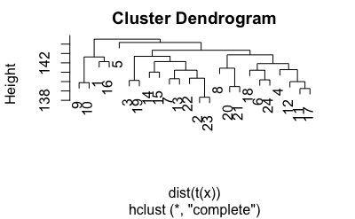

```r
hc = hclust( dist( t(x)))
plot(hc)
```

Hierarchical Clustering Exercises #2 1/1 point (graded) Set the seed at 1 with set.seed(1) and replicate the creation of this matrix 100 times:

```r
m = 10000
n = 24
x = matrix(rnorm(m*n),m,n)
```

then perform hierarchical clustering as in the solution to question 2.4.1 and find the number of clusters if you use cutree() at height 143. Note that this number is a random variable.

Based on the Monte Carlo simulation, what is the standard error of this random variable?

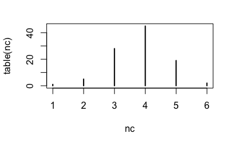

```r
set.seed(1)
m = 10000
n = 24
nc = replicate(100,{
x = matrix(rnorm(m*n),m,n)
hc = hclust( dist( t(x)))
length(unique(cutree(hc,h=143)))
})
plot(table(nc)) ## look at the distribution
```

```r
popsd(nc)
```

[output not shown]

```
Error in popsd(nc) : could not find function "popsd"
```

K-means Exercises

K-means Exercises #1 1 point possible (graded) Run kmeans() with 5 centers for the blood RNA data:

```r
library(GSE5859Subset)
```

```
Error in library(GSE5859Subset) :
  there is no package called ‘GSE5859Subset’
```

Set the seed to 10, set.seed(10), right before running kmeans() with 5 centers.

```r
mds=cmdscale(dist(t(geneExpression)))
```

```
Error in t(geneExpression) : object 'geneExpression' not found
```

Heat Maps Exercises

Heat Maps Exercises #1 1 point possible (graded) Load the data:

```r
library(GSE5859Subset)
data(GSE5859Subset)
```

Pick the 25 genes with the highest across sample variance. This function might help

```r
install.packages("matrixStats")
library(matrixStats)
?rowMads ##we use mads due to a outlier sample
```

While a heatmap function is included in R, we recommend the heatmap.2 function from the gplots package on CRAN because it is a bit more customized. For example, it stretches to fill the window.

```r
library(gplots)
```

```
Error in library(gplots) : there is no package called ‘gplots’
```

Use heatmap.2() to make a heatmap showing the sampleInfo$group with color, the date as labels, the rows labelled with chromosome, and scaling the rows.

```r
##load libraries
library(rafalib)
library(gplots)
```

```
Error in library(gplots) : there is no package called ‘gplots’
```

Heat Maps Exercises #2 1 point possible (graded) Create a large data set of random data that is completely independent of sampleInfo$group like this:

```r
set.seed(17)
m = nrow(geneExpression)
n = ncol(geneExpression)
x = matrix(rnorm(m*n),m,n)
g = factor(sampleInfo$g )
```

Create two heatmaps with these data. Show the group g either with labels or colors.

1. Taking the 50 genes with smallest p-values obtained with rowttests
2. Taking the 50 genes with largest standard deviations.

Which of the following statements is true:

```r
library(gplots)
library(matrixStats)
library(genefilter)
library(RColorBrewer)
cols = colorRampPalette(rev(brewer.pal(11,"RdBu")))(25)

ttest = rowttests(x,g)
sds = rowSds(x)
Indexes = list(t=order(ttest$p.value)[1:50], s=order(-sds)[1:50])
for(ind in Indexes){
 heatmap.2(x[ind,],
          col=cols,
          trace="none",
          scale="row",
          labCol=g,
          key=FALSE)
}
```

[output not shown]